# MC illustration

Required packages:

- `foreach`: for loops.
- `kableExtra`: for nicer tables.
- `doParallel` and `doRNG` for parallel computing.

This document illustrates Monte Carlo (MC) simulations. We consider a regression model with a potentially endogenous regressor. We will use MC simulations to simulate the bias of the OLS estimator under endogeneity, and see how it changes with the strength of endogeneity.

# Data Generating Process (DGP)

The model:

$$\begin{align}
Y_i & = \alpha D_i +X_i'\beta+U_i,\\
D_i & = X_i'\pi + V_i,\\
U_i &= \rho V_i+\epsilon_i,\\
X_{i,1},\ldots,X_{i,k} &\sim\;\text{iid}\; N(0,1),\\
V_i &\sim N(0,1),\\
\epsilon_i &\sim N(0,1).
\end{align}$$

Note that there are no instruments in this model. We will use the following parameters values:

- $\alpha=1$,
- $k=2$,
- $\beta=(\beta_1,\beta_2)'=(1,1)'$,
- $\pi=(\pi_1,\pi_2)'=(1,1)'$.

In this mode, $\rho$ determines the strength of endogeneity of $D_i$. For $\rho=0$, $D_i$ is exogenous, and it is endegenous for $\rho\ne 0$. We will use the following values for $\rho$:

- $\rho\in \{-3,-2,-1,0,1,2,3\}$.

The sample size:

- $n=100$.

### R custom function to simulate data

Since all other parameters except for $\rho$ are not going to vary in this exercise, we define the DGP function as a function of `rho` only.

```r
MyData<-function(rho){
  n<-100
  k<-2
  X<-matrix(rnorm(n*k),ncol=k)
  V<-rnorm(n)
  epsilon<-rnorm(n)

  #D<-X[,1]+X[,2]+V
  D<-rowSums(X)+V

  U<-rho*V+epsilon

  #Y<-D+X[,1]+X[,2]+U
  Y<-D+rowSums(X)+U

  return(list(Y=Y,D=D,X=X))
}
```

```r
Data<-MyData(0)
names(Data)
```

```
## [1] "Y" "D" "X"
```

To access the generated `Y` and `X`, you can use:

- `Data$Y`.
- `Data$D`.
- `Data$X`.

```r
summary(Data$Y)
```

```
##    Min. 1st Qu.  Median    Mean 3rd Qu.    Max.
## -7.2731 -2.2069 -0.1888 -0.2049  2.0667  6.2708
```

```r
summary(Data$D)
```

```
##     Min.  1st Qu.   Median     Mean  3rd Qu.     Max.
## -4.31191 -1.22341  0.33259  0.01925  1.35540  3.84196
```

```r
summary(Data$X)
```

```
##        V1                 V2
##  Min.   :-2.38603   Min.   :-1.99915
##  1st Qu.:-0.70798   1st Qu.:-0.60638
##  Median :-0.00920   Median :-0.12811
##  Mean   :-0.06521   Mean   :-0.05371
##  3rd Qu.: 0.56845   3rd Qu.: 0.38117
##  Max.   : 3.34077   Max.   : 2.36242
```

Note that `X` is a matrix, and `Y` and `D` are vectors:

```r
dim(Data$X)
```

```
## [1] 100   2
```

```r
length(Data$Y)
```

```
## [1] 100
```

```r
length(Data$D)
```

```
## [1] 100
```

# Function to simulate the bias

### Regression with the simulated data

To run a regression with the simulated data:

```r
Reg<-lm(Data$Y~Data$D+Data$X)
summary(Reg)
```

```
##
## Call:
## lm(formula = Data$Y ~ Data$D + Data$X)
##
## Residuals:
##     Min      1Q  Median      3Q     Max
## -1.9242 -0.5845 -0.2452  0.7377  2.4676
##
## Coefficients:
##             Estimate Std. Error t value Pr(>|t|)
## (Intercept) -0.09474    0.10003  -0.947    0.346
## Data$D       0.91503    0.09250   9.892 2.54e-16 ***
## Data$X1      1.07733    0.13226   8.145 1.40e-12 ***
## Data$X2      1.07005    0.14150   7.562 2.37e-11 ***
## ---
## Signif. codes:  0 '***' 0.001 '**' 0.01 '*' 0.05 '.' 0.1 ' ' 1
##
## Residual standard error: 0.9889 on 96 degrees of freedom
## Multiple R-squared:  0.9099, Adjusted R-squared:  0.9071
## F-statistic: 323.3 on 3 and 96 DF,  p-value: < 2.2e-16
```

We can access the coefficient on $D_i$ using:

```r
coef(summary(Reg))[2,1]
```

```
## [1] 0.9150262
```

### Function for the simulated bias

Next, we define a custom function that simulates the bias of the OLS estimator. We will supply two arguments in this case:

- The number of MC repetitions `R`.
- The value of $\rho$.

It is best to use a small `R` when writing and debugging the code, and then switch to a larger `R` for the final run.

```r
Bias<-function(R,rho){
  Alphas<-vector(,R) # we store OLS estimates here
  for (r in 1:R){
    Data<-MyData(rho)
    Reg<-lm(Data$Y~Data$D+Data$X)
    Alphas[r]<-coef(summary(Reg))[2,1]
  }
  bias<-mean(Alphas)-1
  return(bias)
}
```

Let’s check the function with a small `R`:

```r
Bias(10,0.5)
```

```
## [1] 0.4945496
```

# Simulations

The values of $\rho$:

```r
Rho<-c(-3,-2,-1,0,1,2,3)
```

Below, we illustrate the use of `foreach()` from the package `foreach`.

```r
library(foreach)
```

We set the number of MC repetitions to 1,000.

```r
R=10^3
Biases<-foreach(rho=Rho, .combine='cbind') %do% Bias(R,rho)
Biases
```

```
##       result.1  result.2   result.3    result.4  result.5 result.6 result.7
## [1,] -3.002686 -1.995849 -0.9994036 0.004270401 0.9999676 1.998959 3.002028
```

### Seed

Each time we run the simulations code above, we will get slightly different answers as a new random data set generated every time:

```r
Biases<-foreach(rho=Rho, .combine='cbind') %do% Bias(R,rho)
Biases
```

```
##       result.1 result.2  result.3     result.4 result.5 result.6 result.7
## [1,] -2.995806 -1.99876 -1.001523 -0.007686166 1.002158 1.994359 3.000778
```

We can make our results reproducible by fixing the seed so that the same sequence of random numbers is generated each time:

```r
set.seed(6083)
Biases1<-foreach(rho=Rho, .combine='rbind') %do% Bias(R,rho)
```

Let’s repeat:

```r
set.seed(6083)
Biases<-foreach(rho=Rho, .combine='rbind') %do% Bias(R,rho)
```

Let’s compare:

```r
cbind(Biases1,Biases)
```

```
##                  [,1]         [,2]
## result.1 -2.998021180 -2.998021180
## result.2 -2.000653301 -2.000653301
## result.3 -0.997008852 -0.997008852
## result.4  0.001693514  0.001693514
## result.5  0.998217603  0.998217603
## result.6  2.002588697  2.002588697
## result.7  2.997993454  2.997993454
```

You can see now that the results are exactly the same. You can change `6083` to any other number, and as long as you use the same number, the results will be exactly the same:

```r
Biases1-Biases
```

```
##          [,1]
## result.1    0
## result.2    0
## result.3    0
## result.4    0
## result.5    0
## result.6    0
## result.7    0
```

- **Important**: Do not put `set.seed()` inside your DGP function as it will generate the same data set every time.
- We want different data sets generated across different iterations of `r=1:R` so we can average across them.

# Presentation

### Plot

We can now plot the absolute value of the bias against the strength of endogeneity:

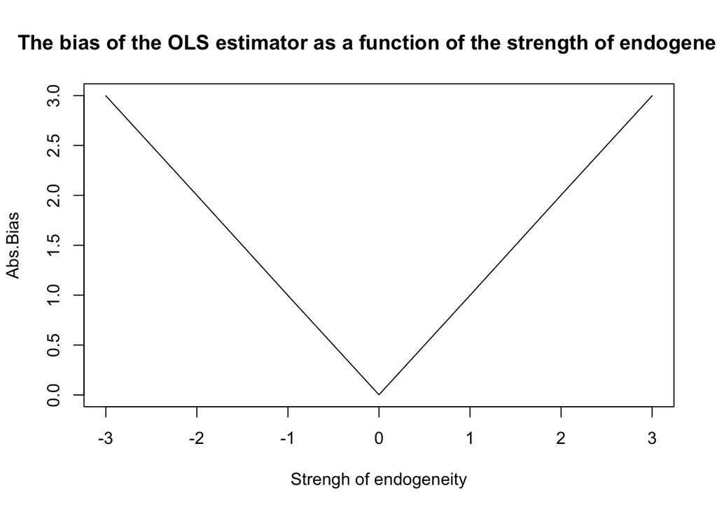

```r
plot(Rho,abs(Biases),type="l",xlab="Strengh of endogeneity",ylab="Abs.Bias",main="The bias of the OLS estimator as a function of the strength of endogeneity")
```

We can see that the absolute value of the bias increases with the strength of endogeneity.

### Table

We can also use the `kableExtra` package to present the results as a nice table

```r
library(kableExtra)
```

First, we combine the results with the values of $\rho$:

```r
OUT<-data.frame("Strenght of Endogeneity"=Rho,"Strenght of Endogeneity"=abs(Biases))
```

Now, we produce the table:

```r
OUT %>%
  kable(digits=2,caption="Bias of the OLS estimator for different values of the endogeneity parameter $\\rho$ ",
        align=c('c','c'),
        col.names=c("Value of $\\rho$","Absolute Bias"),
        row.names=F
        ) %>%
  kable_classic(full_width = F, html_font = "Cambria")
```

Bias of the OLS estimator for different values of the endogeneity parameter $\rho$

| Value of $\rho$ | Absolute Bias |
| --- | --- |
| -3 | 3 |
| -2 | 2 |
| -1 | 1 |
| 0 | 0 |
| 1 | 1 |
| 2 | 2 |
| 3 | 3 |

# Measure CPU time

- You can use `system.time()` too measure the CPU time used to run a code:

```r
system.time(
 foreach(rho=Rho, .combine='rbind') %do% Bias(R,rho)
)
```

```
##    user  system elapsed
##   9.629   0.043   9.673
```

# Parallel computing

We can speed up computations by parallerizing our MC loops over multiple cores. We can use the `doParallel` package to parallerize some of the code:

```r
library(doParallel,quietly=T)
```

You can check the number of available physical cores using:

```r
detectCores(logical=F)
```

```
## [1] 12
```

Next, “register” the cores:

```r
registerDoParallel(detectCores(logical=F))
```

Lastly, replace `%do%` with `%dopar%`:

```r
system.time(
  B<-foreach(rho=Rho, .combine='rbind') %dopar% Bias(R,rho)
)
```

```
##    user  system elapsed
##  10.642   0.714   1.673
```

**Note** the speed gain relatively to the original (non-parallel) code: the elapsed time is reduced!

### Seed and parallel

`set.seed()` does not work with parallel:

```r
set.seed(6081)
B1<-foreach(rho=Rho, .combine='rbind') %dopar% Bias(R,rho)
set.seed(6081)
B2<-foreach(rho=Rho, .combine='rbind') %dopar% Bias(R,rho)
```

You can see that the results are slightly different:

```r
B1-B2
```

```
##                   [,1]
## result.1  0.0048843107
## result.2  0.0007662191
## result.3 -0.0087884887
## result.4 -0.0036589874
## result.5  0.0032375948
## result.6  0.0021669454
## result.7  0.0046398694
```

Instead of `set.seed()`, you can use the `doRNG` package:

```r
library(doRNG,quietly=T)
```

We will specify the seed option, and replace `%dopar%` with `%dorng`:

```r
P1<-foreach(rho=Rho, .options.RNG=6083, .combine='rbind') %dorng% Bias(R,rho)
P2<-foreach(rho=Rho, .options.RNG=6083, .combine='rbind') %dorng% Bias(R,rho)
Compare<-cbind(P1,P2,P1-P2)
colnames(Compare)<-c("1st run","2nd run","difference")
Compare
```

```
##               1st run      2nd run difference
## result.1 -2.999897976 -2.999897976          0
## result.2 -2.001900336 -2.001900336          0
## result.3 -1.003049599 -1.003049599          0
## result.4  0.002420704  0.002420704          0
## result.5  1.006554497  1.006554497          0
## result.6  2.005677432  2.005677432          0
## result.7  3.001866512  3.001866512          0
```

The results are now identical!

Time performance is similar to `%dopar%`:

```r
system.time(
  B<-foreach(rho=Rho, .options.RNG=6083, .combine='rbind') %dorng% Bias(R,rho)
)
```

```
##    user  system elapsed
##  10.675   0.781   1.684
```